# Exercise Set 1

**Instructions:**

- Do not write your name on the assignment. Be careful about any warnings that might display some file path with your name included.
- Receiving help from classmates and/or ideas from Generative AI is allowed. **However, you must submit your own original work.**
- For questions that require coding, you need to write the relevant code and display its output. Your output should either be the direct answer to the question or clearly display the answer in it.
- For questions that require a written answer (sometimes along with the code), you need to put your answer in a Markdown cell. Writing the answer as a comment or as a print line is not acceptable.
- You need to render this file as HTML using Quarto and submit the HTML file. **Please note that this is a requirement and not optional.** A submission cannot be graded until it is properly rendered.

Import all the libraries and tools you need below.

```python
import pandas as pd
from sklearn.model_selection import train_test_split
from sklearn.preprocessing import StandardScaler
from sklearn.linear_model import LogisticRegression
from sklearn.metrics import accuracy_score, recall_score, confusion_matrix
import numpy as np
import matplotlib.pyplot as plt
```

## 1)

This question serves as a warm-up for using scikit-learn objects for different Machine Learning tasks.

You need to use the **BankNote_Authentication.csv** dataset. Each observation is a banknote. The response variable, named `class`, represents whether the banknote is forged (1) or authentic (0). All other variables are the features and they represent a number of statistical measures extracted from the images of the banknotes.

### a)

Read the data as a DataFrame. **(5 points)**

```python
df = pd.read_csv("BankNote_Authentication.csv")

df
```

|  | variance | skewness | curtosis | entropy | class |
| --- | --- | --- | --- | --- | --- |
| 0 | 3.62160 | 8.66610 | -2.8073 | -0.44699 | 0 |
| 1 | 4.54590 | 8.16740 | -2.4586 | -1.46210 | 0 |
| 2 | 3.86600 | -2.63830 | 1.9242 | 0.10645 | 0 |
| 3 | 3.45660 | 9.52280 | -4.0112 | -3.59440 | 0 |
| 4 | 0.32924 | -4.45520 | 4.5718 | -0.98880 | 0 |
| ... | ... | ... | ... | ... | ... |
| 1367 | 0.40614 | 1.34920 | -1.4501 | -0.55949 | 1 |
| 1368 | -1.38870 | -4.87730 | 6.4774 | 0.34179 | 1 |
| 1369 | -3.75030 | -13.45860 | 17.5932 | -2.77710 | 1 |
| 1370 | -3.56370 | -8.38270 | 12.3930 | -1.28230 | 1 |
| 1371 | -2.54190 | -0.65804 | 2.6842 | 1.19520 | 1 |

1372 rows × 5 columns

### b)

Explore the data with Python tools to answer the following questions:

- Is this a binary or a multi-class classification task?
- How many observations and features do you have? (The response is not a feature!)
- Is there any missing data?
- **(10 points)**

```python
# Binary or Multi-Class?

classes = df['class'].unique()
print(len(classes))
print(classes)

# Binary
```

```
2
[0 1]
```

```python
# observations and features

print(f"Observations: {len(df)}")
print(f"Features: {len(df.columns) - 1}")
```

```
Observations: 1372
Features: 4
```

```python
# missing data
print(df.isnull().sum())

# see if there are any zero values in the features (not taking into the account the class column)
print((df.drop(columns="class") == 0).sum().sum())
```

```
variance    0
skewness    0
curtosis    0
entropy     0
class       0
dtype: int64
0
```

- Is this a binary or a multi-class classification task?
  - Binary
- How many observations and features do you have? (The response is not a feature!)
  - Observations: 1372
  - Features: 4
- Is there any missing data?
  - No

### c)

Split the data into training and test sets with a 70%-30% ratio. Use `random_state=42` for reproducible results. Make sure that the class ratio is kept the same across the training and the test set.

Note that in order to create the training and test sets, you first need to separate the features and the response into two variables, so you can use them as proper inputs.

**(10 points)**

```python
X = df.drop(columns="class")
y = df["class"]

X_train, X_test, y_train, y_test = train_test_split(X, y, test_size=0.30, random_state=42, stratify=y)
```

### d)

(Standard) scale the training and test sets. **(15 points)**

```python
scale = StandardScaler()

X_train_scaled = scale.fit_transform(X_train)
X_test_scaled = scale.transform(X_test)
```

### e)

Create and train a Logistic Regression model. (You are expected to know which set to use to train the model.) Do **not** use any Lasso or Ridge penalty.

**(15 points)**

```python
model = LogisticRegression(penalty=None)

model.fit(X_train_scaled, y_train)
```

```
LogisticRegression(penalty=None)
```

### f)

Evaluate the model by printing its accuracy, recall and confusion matrix. (You are expected to know which set to use to evaluate the model.) You can assume that the probability threshold is 0.5, which is the default value.

**(20 points)**

```python
y_pred = model.predict(X_test_scaled)

accuracy = accuracy_score(y_test, y_pred)
recall = recall_score(y_test, y_pred)
matrix = confusion_matrix(y_test, y_pred)

print("Accuracy:", accuracy)
print("Recall:", recall)
matrix
```

```
Accuracy: 0.9878640776699029
Recall: 0.994535519125683
```

```
array([[225,   4],
       [  1, 182]])
```

With an accuracy of 98.8% and a recall of 99.5%, the model performs really well on the test set.

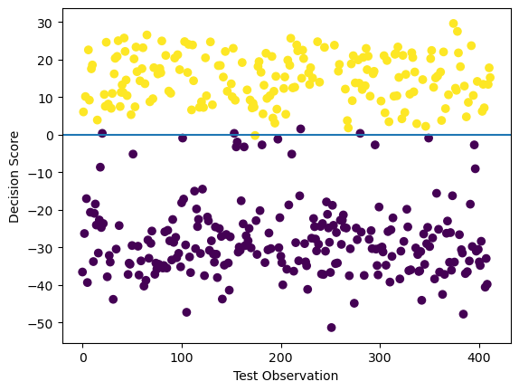

```python
# some extra visualization for myself

scores = model.decision_function(X_test_scaled)

plt.scatter(range(len(scores)), scores, c=y_test)

plt.xlabel("Test Observation")
plt.ylabel("Decision Score")
plt.axhline()

plt.show()
```

### g)

Did you use any hyperparameters in the classifier? Was there anything to cross-validate in the classifier? **(15 points)**

**Note:** The decision threshold is not considered a hyperparameter, as it is not a part of the model itself.

No. Because the LogReg model did not use Lasso (L1) or Ridge (L2), there were no hyperparameters to tune using cross-validation.

## 2)

In this question, you need to create a user-defined function. It will be part of the Gradient Descent code you will put together next week.

Define a function called `initialize`. It should take one scalar numeric input, called `dim`, and return a **(dim + 1) x 1** vector of random numbers. **Note that the output should be a numpy vector.** You do not need to check or account for any invalid inputs.

You can use the given test cases to check your function. You need to sample the random numbers from a uniform distribution between 0 and 1 to match the given answers.

**(10 points)**

```python
def initialize(dim):
    return np.random.rand(dim + 1)

np.random.seed(123)

# test cases
print(initialize(4)) # Should produce [0.69646919 0.28613933 0.22685145 0.55131477 0.71946897]
print(initialize(2)) # Should produce [0.42310646 0.9807642  0.68482974]
print(initialize(7)) # Should produce [0.4809319  0.39211752 0.34317802 0.72904971 0.43857224 0.0596779 0.39804426 0.73799541]
```

```
[0.69646919 0.28613933 0.22685145 0.55131477 0.71946897]
[0.42310646 0.9807642  0.68482974]
[0.4809319  0.39211752 0.34317802 0.72904971 0.43857224 0.0596779
 0.39804426 0.73799541]
```

```python
np.random.seed(123)

print(np.allclose(initialize(4), [0.69646919, 0.28613933, 0.22685145, 0.55131477, 0.71946897]))
print(np.allclose(initialize(2), [0.42310646, 0.9807642, 0.68482974]))
print(np.allclose(initialize(7), [0.4809319, 0.39211752, 0.34317802, 0.72904971, 0.43857224, 0.0596779, 0.39804426, 0.73799541]))
```

```
True
True
True
```